# Shiny as a platform for collaborative data exploration

Budapest BI Forum 2015, 2015.10.14.

## About us

## The company

- system/process analysis and optimization "consulting"
- automotive tooling development
- **R&D spinoff**
  - founders: professors & and lecturers
  - [**Dept. of Measurement and Inf. Systems**](http://www.inf.mit.bme.hu) @BME
  - course highlights: 'Big Data' Analysis Techniques, Cyber-Physical Systems, Intelligent Data Analysis, System Modelling
- **[Budapest R meetup](http://www.meetup.com/budapest-users-of-r-network/)**: pizza, beer, presentations, 2 organizers

## Data analysis competencies at Quanopt

**Critical cloud applications**

Manufacturing processes

Electronic equipment testing

Effort models for safety-critical software development processes

Fraud detection for service provider

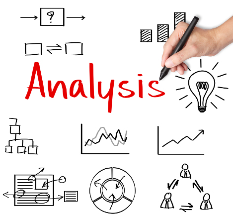

## Quanopt and R

You touch data - you have to speak some R (and you will see the light, we promise)

But a **manageable** investment - stats is the hard part, lang is easy

- Main use cases
  - **Visualization**: R is nigh unbeatable
  - "Exploratory Data Analysis"
  - Modeling - from descriptive models to [neural networks](http://www.inside-r.org/howto/time-series-analysis-and-order-prediction-r)
  - Data cleaning and tidying

## Shiny: an overview

## Shiny: a web framework for R

From [RStudio](http://shiny.rstudio.com/)  
Web page layout and logic: write an R function

Server logic: write an R function

Page updates: reactive network of variables (as in Excel)  
Run locally (RStudio!) / on shiny server / http://shinyapps.io

## A simplistic example

ui.R

```r
shinyUI(fluidPage(
  selectInput("iris_mvar",
    "Iris property:",
    choices=colnames(iris)[1:4]),
    plotOutput("boxplot")))
```

server.R

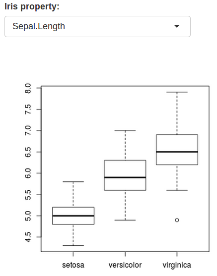

```r
shinyServer(
  function(input,output){
    output$boxplot <- renderPlot(
      boxplot(get(input$iris_mvar) ~
      Species, data=iris))}))
```

## Reactive programming

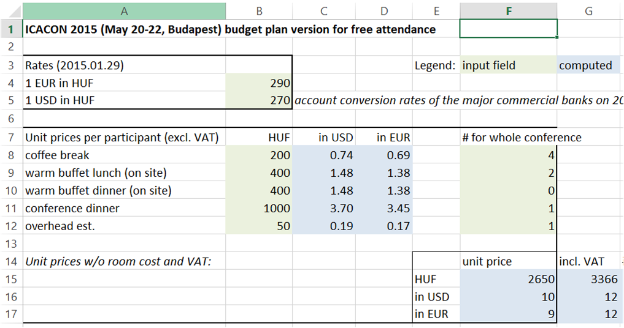

Note: prices have been obfuscated

## Reactive programming

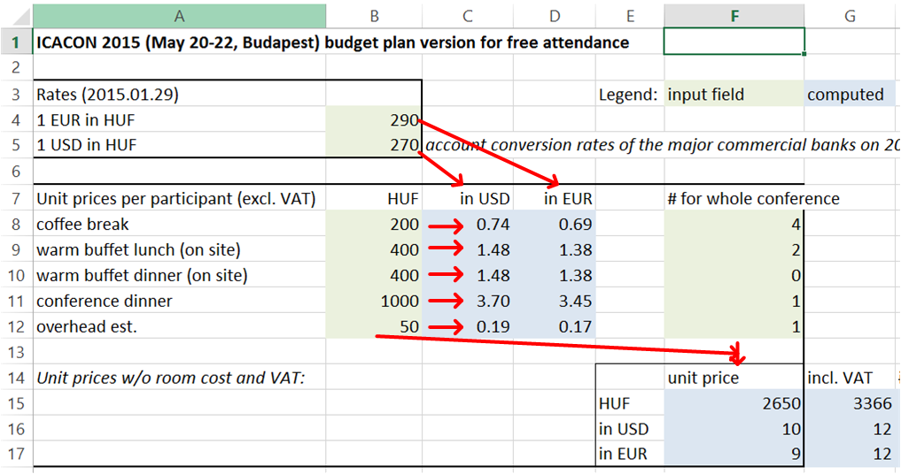

## Reactive programming

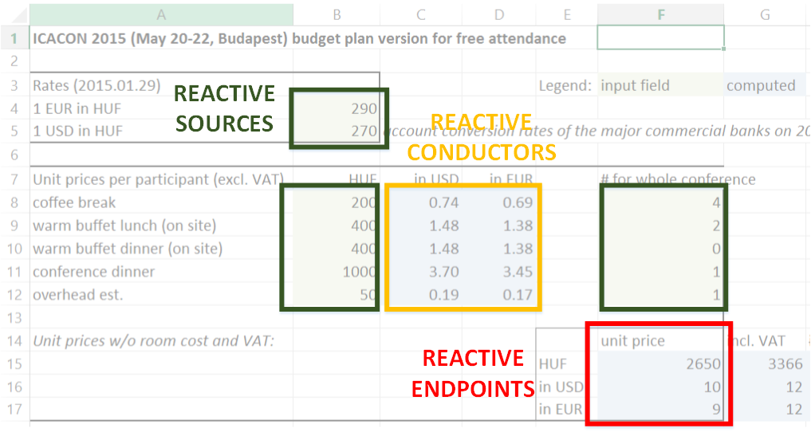

## Tweets mentioning "BudapestBI" - query with button

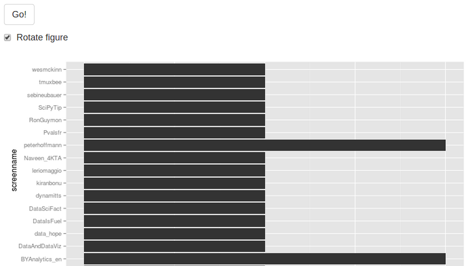

## The code - server

```r
function(input, output){
    currenttweets <- reactive({
      a <- NULL
      if(input$goButton > 0) {
        a <- bitweeters()}
      a
    })

    output$biplot <- renderPlot({
      p <- qplot(screenname, data=currenttweets(), geom="bar")
      if(input$rotate) {p <- p + coord_flip()}
      print(p)
    })
```

## And for the sake of completeness

```r
library(twitteR)
library(ggplot2)

bitweeters <- function(){
  origop <- options("httr_oauth_cache")
  options(httr_oauth_cache=TRUE)
  setup_twitter_oauth(conskey,conssecr,actok, acsecr)
  options(httr_oauth_cache=origop)

  tweets <- searchTwitter("BudapestBI", n = 100)

  scrn <- sapply(tweets, screenName)
  crtd <- sapply(tweets, created)

  data.frame(screenname=scrn, created=crtd)
}
```

## Invalidation and recomputation

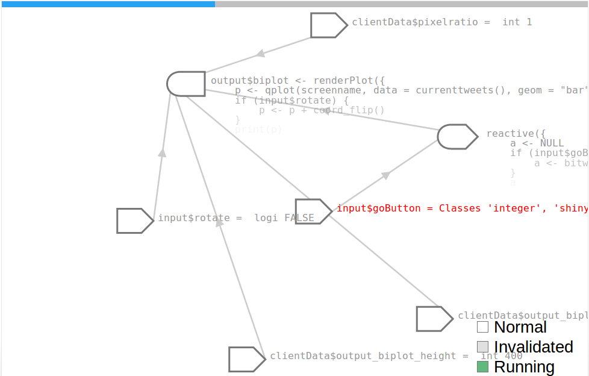

## Other technicalities

- you can isolate the usage of a reactive var
- observers for side effects upon changes
- all the usual HTML inputs
- reasonable layout control
- reasonable set of outputs (with renderers) + htmlwidgets
- UI customization: HTML, JavaScript, CSS
- server function can have session parameter
- **important, but not covered: interactive graphics**

## Dynamic UI

### or towards intractable hacking

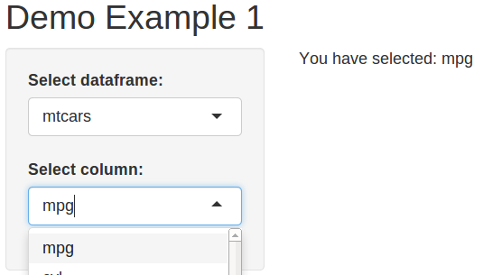

## renderUI for uiOutput

```r
function(input, output) {
  output$colselect <- renderUI({
    if(input$dataSelect == "cars") {
      selectInput("colSelect", "Select column:", names(dataframe1))
    } else {
      selectInput("colSelect", "Select column:", names(dataframe2))
    }
  })

  output$selected <- renderText({
    paste("You have selected: ", input$colSelect)
  })}
```

Could be different control types

And you can do cascading (**but don't**!)

## Use case #1

### EDA on public cloud benchmark campaigns

## Scenario

Cloud automation & availability project

An awful lot of perf. benchmark campaigns

To specify "the plots" for the Big BI DW Tool

R/Shiny begun as a band-aid

[figure not shown]

## Results

[figure not shown]

## Lessons learned

Very positive reception (Because shiny.)

In the given context: visualization >> "statistics"

First usable prototypes: very fast

Put it in a VPN - and suddenly it's a tool for **collaboration**

DB normalization and evolution massively worked against us

Deep, dynamic tree of DB-driven input controls: **AVOID!**

The whole thing got a bit sluggish (mostly ggplot2)

## If it works… (?)

## Similar projects, similar usage

Electronic equipment testing (BIG data)

**Currently: fault injection on telco cloud applications**

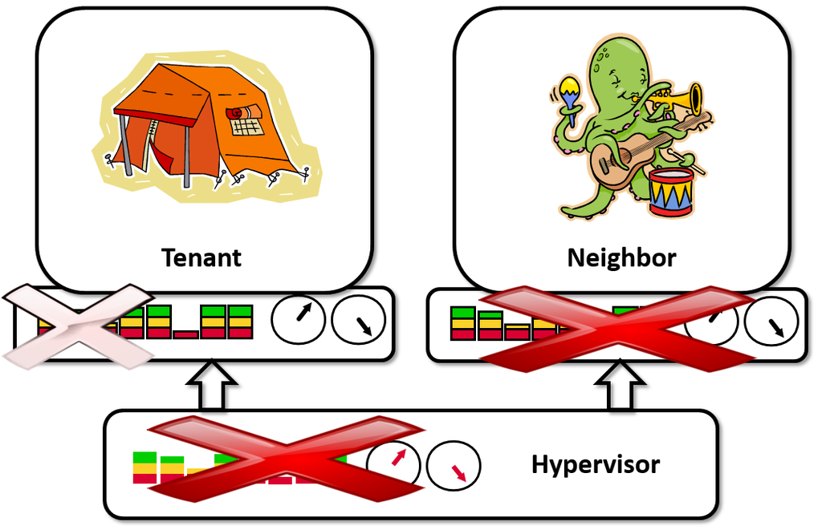

Web-based, "mouse-only" exploration

Small teams, project-internal usage; findings recorded separately

Source of all griefs: ID variables

## "Decision making support"

### Let stakeholders convince themselves

## Educational cloud: Apache VCL

[figure not shown]

## How do students behave?

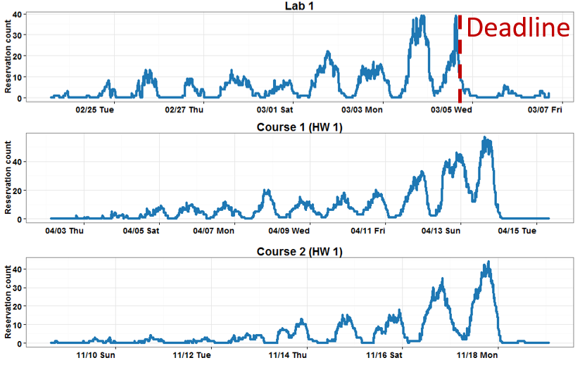

## The app

[figure not shown]

## My impression of shiny

## Shiny: pro's

- Inside its design envelope: a breeze
- For me this includes no JavaScript
- Almost full R ecosystem
- By far not only "toy apps"
- … But you probably want to stop at "workgroup applications"

## Shiny: con's and things to keep in mind

- No notion of
  - page flow (single page)
  - analysis flow
  - recording & replaying app state
- Keep layout dynamics unsophisticated
- Is the reactive model really enough for you?
- You still develop R (with "reactivity") - maintenance?

## Shiny: con's and things to keep in mind

- Stepping out of the box: R scripting morphs into web development
- Don't confuse it with full-fledged tools (no Watson for free)
- optimal case: your code and data in R; OR you need something from R
- This can be simply ggplot2, mind you
- Server/PaaS pricing
- (Interactive graphics - incl. linked selection & highlighting)

## Final thoughts

- Fun! :)
- Check it out: http://shiny.rstudio.com
- Professional setting: think about the risks (and whys)
- Under development: making objects of the analyzed system first-class citizens in shiny-based visualization
- Currently: too observation-based (interpretation?)

## Thanks

http://quanopt.com

Dynamic presentation: https://github.com/imrekocsis/biforum2015

**Mail**  
kocsis@quanopt.com  
ikocsis@mit.bme.hu

**Special thanks from the team to**  
László Gönczy, Gergő Kincses, Ágnes Salánki, György Nádudvari